# Titanic data - investigate a dataset

# Investigation of Question 1

Was the "Women and child first" code of conduct applied?This code means that the lives of women and children were to be saved first in a life-threatening situation, typically when abandoning the ship, when survival resources such as lifeboats were limited. For this I have to check two main demografic groups: women and children, which in my dataset means that I need to create new categories: male, female and child. So first define child as under the age of 14.

```python
def male_female_child(passenger):
    age, sex = passenger
    if age < 14:
        return 'child'
    else:
        return sex

titanic_data['New_passenger'] = titanic_data[['Age', 'Sex']].apply(male_female_child, axis=1)
```

```python
# Check the new column we added
titanic_data.head()
```

|  | PassengerId | Survived | Pclass | Name | Sex | Age | SibSp | Parch | Ticket | Fare | Cabin | Embarked | Survival | Class | Ports | New_passenger |
| --- | --- | --- | --- | --- | --- | --- | --- | --- | --- | --- | --- | --- | --- | --- | --- | --- |
| 0 | 1 | 0 | 3 | Braund, Mr. Owen Harris | male | 22.0 | 1 | 0 | A/5 21171 | 7.2500 | NaN | S | Died | Third Class | Southampton | male |
| 1 | 2 | 1 | 1 | Cumings, Mrs. John Bradley (Florence Briggs Th... | female | 38.0 | 1 | 0 | PC 17599 | 71.2833 | C85 | C | Survived | First Class | Cherbourg | female |
| 2 | 3 | 1 | 3 | Heikkinen, Miss. Laina | female | 26.0 | 0 | 0 | STON/O2. 3101282 | 7.9250 | NaN | S | Survived | Third Class | Southampton | female |
| 3 | 4 | 1 | 1 | Futrelle, Mrs. Jacques Heath (Lily May Peel) | female | 35.0 | 1 | 0 | 113803 | 53.1000 | C123 | S | Survived | First Class | Southampton | female |
| 4 | 5 | 0 | 3 | Allen, Mr. William Henry | male | 35.0 | 0 | 0 | 373450 | 8.0500 | NaN | S | Died | Third Class | Southampton | male |

```python
# as there are no children in the first 5 rows, lets check another 5 rows
titanic_data[5:10]
```

|  | PassengerId | Survived | Pclass | Name | Sex | Age | SibSp | Parch | Ticket | Fare | Cabin | Embarked | Survival | Class | Ports | New_passenger |
| --- | --- | --- | --- | --- | --- | --- | --- | --- | --- | --- | --- | --- | --- | --- | --- | --- |
| 5 | 6 | 0 | 3 | Moran, Mr. James | male | NaN | 0 | 0 | 330877 | 8.4583 | NaN | Q | Died | Third Class | Queenstown | male |
| 6 | 7 | 0 | 1 | McCarthy, Mr. Timothy J | male | 54.0 | 0 | 0 | 17463 | 51.8625 | E46 | S | Died | First Class | Southampton | male |
| 7 | 8 | 0 | 3 | Palsson, Master. Gosta Leonard | male | 2.0 | 3 | 1 | 349909 | 21.0750 | NaN | S | Died | Third Class | Southampton | child |
| 8 | 9 | 1 | 3 | Johnson, Mrs. Oscar W (Elisabeth Vilhelmina Berg) | female | 27.0 | 0 | 2 | 347742 | 11.1333 | NaN | S | Survived | Third Class | Southampton | female |
| 9 | 10 | 1 | 2 | Nasser, Mrs. Nicholas (Adele Achem) | female | 14.0 | 1 | 0 | 237736 | 30.0708 | NaN | C | Survived | Second Class | Cherbourg | female |

```python
# now we can check how many child were on board
titanic_data['New_passenger'].value_counts()
```

```
male      540
female    280
child      71
Name: New_passenger, dtype: int64
```

```python
# let's check with a pivot what are the means and what was the survival rate of our newly created passenger categories
pd.pivot_table(titanic_data,index=["New_passenger"], values=["Survived"])
```

| New_passenger | Survived |
| --- | --- |
| child | 0.591549 |
| female | 0.757143 |
| male | 0.162963 |

The survival rate for children was 59%, for females 76% and for males 16%. To see if there is a peek of highest survival ratio within children let's visualise our data.

### Visualisations of Question 1

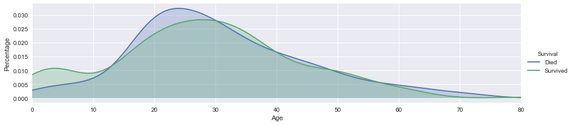

```python
plot = sns.FacetGrid(titanic_data, hue='Survival', aspect=4)

plot.map(sns.kdeplot, 'Age', shade=True)
oldest = titanic_data['Age'].max()
plot.set(xlim=(0, oldest))
plt.ylabel("Percentage")
plot.add_legend()
```

The chart above shows a peek in the survival group within the 0-10 age range. On the other hand we can see that somewhere between 20 and 25 age range the chances to survive were less than not. Let's check if there are other age ranges where the survival rate is higher than the mortality rate.

```python
#Remove the rows where Age data is missing then divide into age ranges
cleaned_age = titanic_data[titanic_data['Age'].notnull()].copy()

def cutDF(df):
    return pd.cut(df, [0,10,20,30,40,50,60,70,80], labels=['0-9', '10-19', '20-29','30-39','40-49','50-59','60-69','70-80'])

cleaned_age['Age_range'] = cleaned_age[['Age']].apply(cutDF)
```

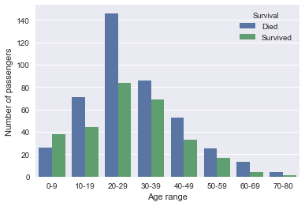

```python
count1 = cleaned_age.groupby(['Age_range','Survival']).count().reset_index()
sns.barplot(x='Age_range',y='PassengerId', hue="Survival", data=count1)
plt.xlabel("Age range")
plt.ylabel("Number of passengers")
```

Tha chart above confirms that there is only age range 0-9 where the survival rate is higher. Of course we could create smaller bins, but I have decided to use this bin size to get good visualisation. Another point to highlight is that according to the previous chart we also get confirmation for the relatively high mortality rate in the age range 20-29.

# Investigation of Question 2

Did lower fare passengers and 2nd or 3rd class passenger have less chance to reach the life boats?

```python
pd.pivot_table(titanic_data,index=["Class","New_passenger", ], values=["Survived"])
```

| Class | New_passenger | Survived |
| --- | --- | --- |
| First Class | child | 0.750000 |
|  | female | 0.978495 |
|  | male | 0.352941 |
| Second Class | child | 1.000000 |
|  | female | 0.910448 |
|  | male | 0.080808 |
| Third Class | child | 0.428571 |
|  | female | 0.500000 |
|  | male | 0.118012 |

Let's analyze the child category first, on the 1st class had 75%, on the 2nd class had 100% survival rate, while on the 3rd class only 43% survived, so children traveling on 1st or 2nd class had higher survival rates. Females on the 1st class had 98%, on the 2nd class had 91% survival rate, while on the 3rd class only 50% survived, so women traveling on 1st or 2nd class had higher survival rates. Males on the 1st class had 35%, on the 2nd class had 8% survival rate, while on the 3rd class 11% survived, so men traveling on 1st class had highest survival rates.

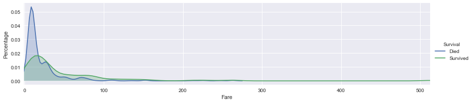

```python
plot = sns.FacetGrid(titanic_data, hue='Survival', aspect=4)

plot.map(sns.kdeplot, 'Fare', shade=True)
most_expensive = titanic_data['Fare'].max()
plot.set(xlim=(-1, most_expensive))
plt.ylabel("Percentage")
plot.add_legend()
```

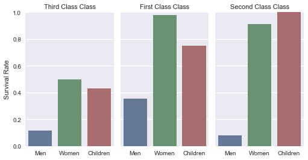

```python
>>> g = sns.factorplot(x="New_passenger", y="Survived", col="Class",
...                    data=titanic_data, saturation=.5,
...                    kind="bar", ci=None, aspect=.6)
>>> (g.set_axis_labels("", "Survival Rate")
...   .set_xticklabels(["Men", "Women", "Children"])
...   .set_titles("{col_name} {col_var}")
...   .set(ylim=(0, 1))
...   .despine(left=True))
```

## Limitations of the analysis

We have to highlight the limitations of our analysis. First of all as discussed it in the first session we don't have information about all the passangers and we don't have any information when and how this database was collected. Even if we assume that these data is representative for the whole passenger group we do have missing values in Age, Cabin and Embarked columns.

In case of the age we could have impute the average for the missing values or we could delete the rows with missing values, but simply we left these out from our calculation,. With use average we would have more data to work with, but on the other hand also assume that we have a representative input without outliers. With deleting the rows we lost information. So both solution has it's limitations. In case of the age I have defined an age range, maybe this could be also adjusted to the historical definition.

On these data we couldn't use any statistical test, just found some tendencies. We have seen correlations, but it does not imply causation. Like maybe the higher survival rate in first class was just because of the fact that those passengers were closer to the deck where all the all the life boats were.

It would be good to have more detailed information in the family members category and dive deeper into those ones.

```python
Sources
https://www.kaggle.com/c/titanic/data
https://en.wikipedia.org/wiki/Women_and_children_first
https://en.wikipedia.org/wiki/RMS_Titanic
https://seaborn.pydata.org/generated/seaborn.factorplot.html?highlight=factorplot#seaborn.factorplot
https://seaborn.pydata.org/generated/seaborn.heatmap.html
```